# Table of Contents

## Chapter Goals

1. Understand the basics of stationarity
2. Understand how asset returns violate the rules of stationarity
3. Demonstrate that concept that asset returns can be considered as being generated by different distributions
4. Motivating the use of a more robust prediction methodology

## Getting and Storing a Dataset

Start by importing the required modules and tools

### Getting Stock Data

Morningstar, Yahoo and Google finance data are now deprecated. To get free adjusted close data, sign up with [Tiingo](https://www.tiingo.com/account/billing/pricing) to get an API key. We'll get the closing price for multiple ETFs. In this case I have already downloaded and saved the prices and returns for several ETFs.

```python
R = pd.read_parquet(data_dir / "tiingo_etf_returns_ending_2017-12-31.parq").assign(
    year=lambda df: df.index.year
)
cprint(R)
```

```
-------------------------------------------------------------------------------
dataframe information
-------------------------------------------------------------------------------
               SPY     QQQ     TLT    GLD     EFA     EEM  year
date
2017-12-22 -0.0003 -0.0011  0.0014 0.0052  0.0026  0.0084  2017
2017-12-26 -0.0012 -0.0054  0.0030 0.0068 -0.0003 -0.0009  2017
2017-12-27  0.0005  0.0001  0.0129 0.0038  0.0019  0.0026  2017
2017-12-28  0.0021  0.0012 -0.0009 0.0051  0.0006  0.0068  2017
2017-12-29 -0.0038 -0.0062  0.0016 0.0065  0.0007  0.0047  2017
--------------------------------------------------
<class 'pandas.core.frame.DataFrame'>
DatetimeIndex: 3301 entries, 2004-11-19 to 2017-12-29
Data columns (total 7 columns):
SPY     3301 non-null float64
QQQ     3301 non-null float64
TLT     3301 non-null float64
GLD     3301 non-null float64
EFA     3301 non-null float64
EEM     3301 non-null float64
year    3301 non-null int64
dtypes: float64(6), int64(1)
memory usage: 206.3 KB
None
-------------------------------------------------------------------------------
```

Please be aware that the load function used above immediately converts the `parquet` file into a `pandas.DataFrame` object. For smaller datasets and modern laptop hardware that is not a problem (less than 1 `gb`). However once your dataset starts getting into the multi `gb` range one might experience delayed performance in which case I would recommend learning and using [Dask](http://dask.pydata.org/en/latest/).

## Defining Stationarity

The following image sums up this concept best. The simple intuition is that the series mean and variance should NOT change as a result of passing time. The covariance between returns in the time series should also NOT be a function of time.

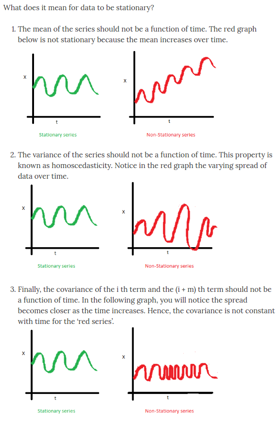

```python
Image(filename=media, height=400, width=400)
```

### Are These Series Stationary?

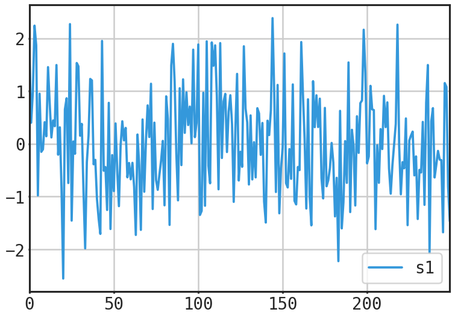

```python
Image(visual_dir / "s1.png")
```

```python
display(kpss_test(s1))
display(adf_test(s1))
```

```
 KPSS Result: The series is stationary
```

|  | test_stat | pval | 1% | 5% | 10% |
| --- | --- | --- | --- | --- | --- |
| s1 | 0.1819 | 0.1000 | 0.7390 | 0.4630 | 0.3470 |

```
 ADF Result: The series is stationary
```

|  | test_stat | pval | 1% | 5% | 10% |
| --- | --- | --- | --- | --- | --- |
| s1 | -15.4291 | 0.0000 | -3.9956 | -3.4283 | -3.1375 |

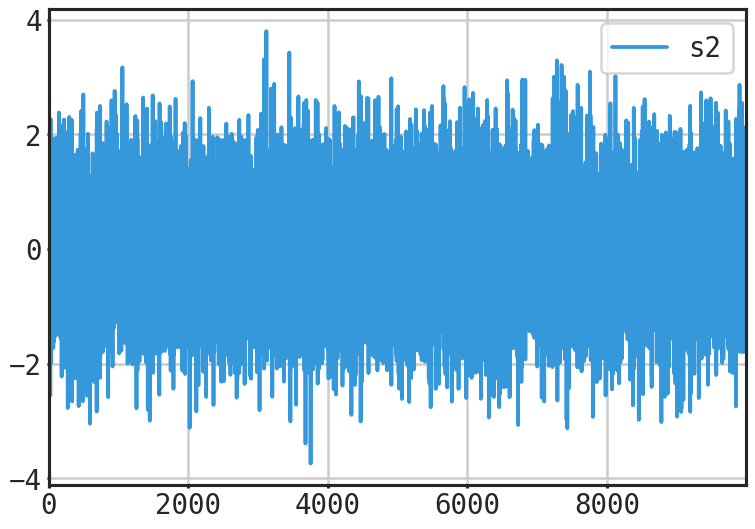

```python
Image(visual_dir / "s2.png")
```

```python
display(kpss_test(s2))
display(adf_test(s2))
```

```
 KPSS Result: The series is stationary
```

|  | test_stat | pval | 1% | 5% | 10% |
| --- | --- | --- | --- | --- | --- |
| s2 | 0.0741 | 0.1000 | 0.7390 | 0.4630 | 0.3470 |

```
 ADF Result: The series is stationary
```

|  | test_stat | pval | 1% | 5% | 10% |
| --- | --- | --- | --- | --- | --- |
| s2 | -99.4853 | 0.0000 | -3.9597 | -3.4109 | -3.1273 |

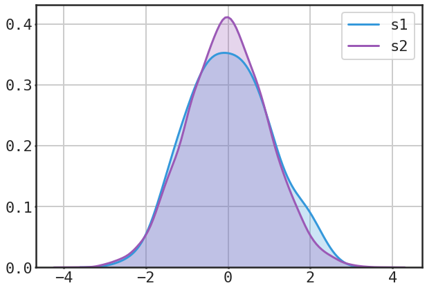

```python
g = sns.kdeplot(s1, shade=True)
g = sns.kdeplot(s2, shade=True)
```

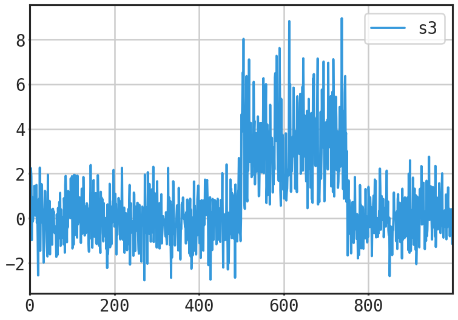

```python
Image(visual_dir / "s3.png")
```

```python
display(kpss_test(s3))
display(adf_test(s3))
```

```
 KPSS Result: The series is not stationary
```

|  | test_stat | pval | 1% | 5% | 10% |
| --- | --- | --- | --- | --- | --- |
| s3 | 0.9167 | 0.0100 | 0.7390 | 0.4630 | 0.3470 |

```
 ADF Result: The series is not stationary
```

|  | test_stat | pval | 1% | 5% | 10% |
| --- | --- | --- | --- | --- | --- |
| s3 | -2.5014 | 0.3273 | -3.9680 | -3.4149 | -3.1297 |

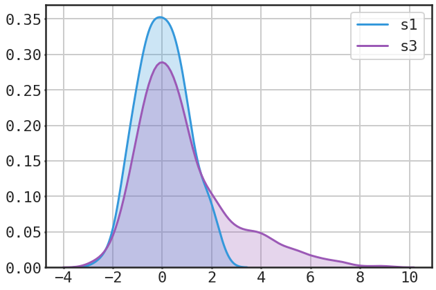

```python
g = sns.kdeplot(s1, shade=True)
g = sns.kdeplot(s3, shade=True)
```

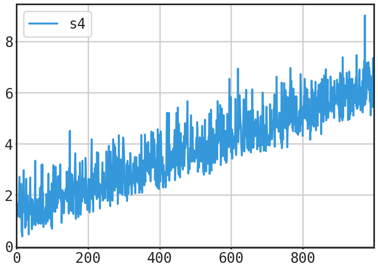

```python
Image(visual_dir / "s4.png")
```

```python
display(kpss_test(s4))
display(adf_test(s4))
```

```
 KPSS Result: The series is not stationary
```

|  | test_stat | pval | 1% | 5% | 10% |
| --- | --- | --- | --- | --- | --- |
| s4 | 4.3964 | 0.0100 | 0.7390 | 0.4630 | 0.3470 |

```
 ADF Result: The series is stationary
```

|  | test_stat | pval | 1% | 5% | 10% |
| --- | --- | --- | --- | --- | --- |
| s4 | -19.7645 | 0.0000 | -3.9679 | -3.4149 | -3.1296 |

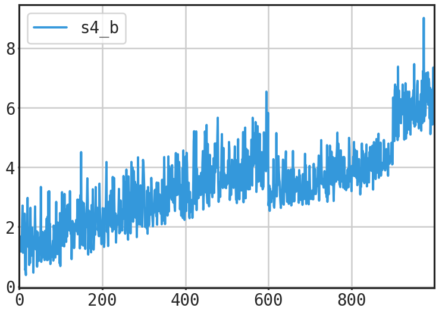

```python
Image(visual_dir / "s4_b.png")
```

```python
display(kpss_test(s4_b))
display(adf_test(s4_b))
```

```
 KPSS Result: The series is not stationary
```

|  | test_stat | pval | 1% | 5% | 10% |
| --- | --- | --- | --- | --- | --- |
| s4_b | 3.5062 | 0.0100 | 0.7390 | 0.4630 | 0.3470 |

```
 ADF Result: The series is not stationary
```

|  | test_stat | pval | 1% | 5% | 10% |
| --- | --- | --- | --- | --- | --- |
| s4_b | -1.8177 | 0.6961 | -3.9680 | -3.4150 | -3.1297 |

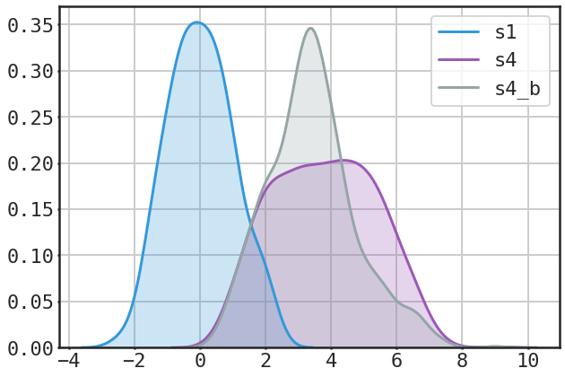

```python
g = sns.kdeplot(s1, shade=True)
g = sns.kdeplot(s4, shade=True)
g = sns.kdeplot(s4_b, shade=True)
```

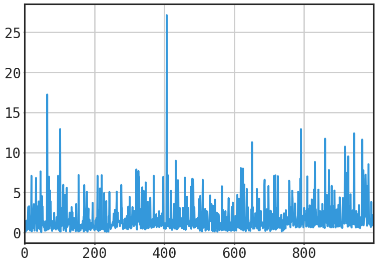

```python
Image(visual_dir / "s5.png")
```

```python
display(kpss_test(s5))
display(adf_test(s5))
```

```
 KPSS Result: The series is not stationary
```

|  | test_stat | pval | 1% | 5% | 10% |
| --- | --- | --- | --- | --- | --- |
| s5 | 0.7308 | 0.0107 | 0.7390 | 0.4630 | 0.3470 |

```
 ADF Result: The series is stationary
```

|  | test_stat | pval | 1% | 5% | 10% |
| --- | --- | --- | --- | --- | --- |
| s5 | -23.2672 | 0.0000 | -3.9679 | -3.4149 | -3.1296 |

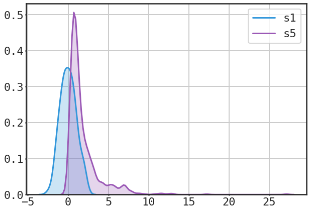

```python
g = sns.kdeplot(s1, shade=True)
g = sns.kdeplot(s5, shade=True)
```

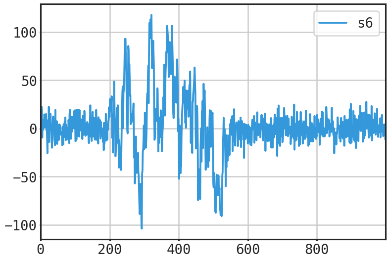

```python
Image(visual_dir / "s6.png")
```

```python
display(kpss_test(s6))
display(adf_test(s6))
```

```
 KPSS Result: The series is stationary
```

|  | test_stat | pval | 1% | 5% | 10% |
| --- | --- | --- | --- | --- | --- |
| s6 | 0.2064 | 0.1000 | 0.7390 | 0.4630 | 0.3470 |

```
 ADF Result: The series is stationary
```

|  | test_stat | pval | 1% | 5% | 10% |
| --- | --- | --- | --- | --- | --- |
| s6 | -6.6085 | 0.0000 | -3.9679 | -3.4149 | -3.1296 |

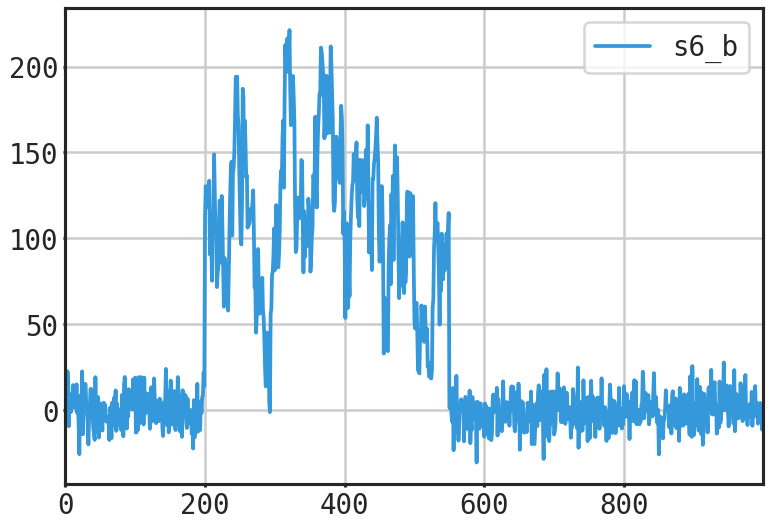

```python
Image(visual_dir / "s6_b.png")
```

```python
display(kpss_test(s6_b))
display(adf_test(s6_b))
```

```
 KPSS Result: The series is not stationary
```

|  | test_stat | pval | 1% | 5% | 10% |
| --- | --- | --- | --- | --- | --- |
| s6_b | 1.1899 | 0.0100 | 0.7390 | 0.4630 | 0.3470 |

```
 ADF Result: The series is not stationary
```

|  | test_stat | pval | 1% | 5% | 10% |
| --- | --- | --- | --- | --- | --- |
| s6_b | -2.9081 | 0.1596 | -3.9679 | -3.4149 | -3.1297 |

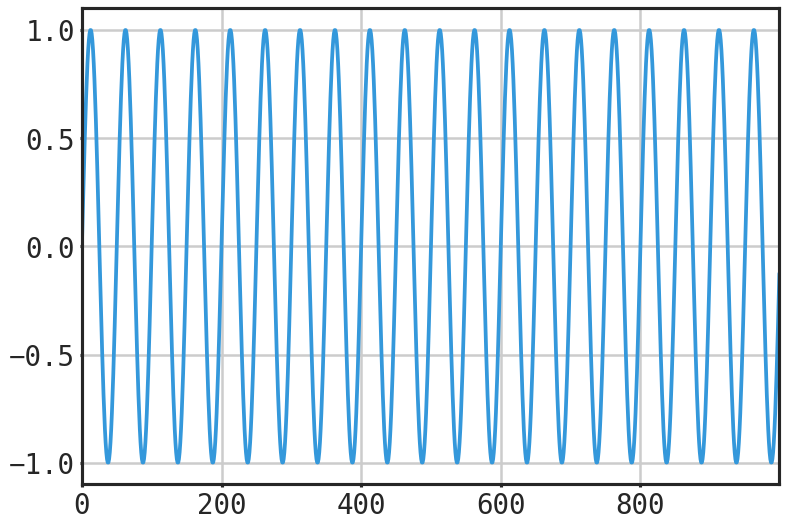

```python
Image(visual_dir / "s7.png")
```

```python
display(kpss_test(s7))
display(adf_test(s7))
```

```
 KPSS Result: The series is stationary
```

|  | test_stat | pval | 1% | 5% | 10% |
| --- | --- | --- | --- | --- | --- |
| NaN | 0.0173 | 0.1000 | 0.7390 | 0.4630 | 0.3470 |

```
 ADF Result: The series is stationary
```

|  | test_stat | pval | 1% | 5% | 10% |
| --- | --- | --- | --- | --- | --- |
| NaN | -64,154,063,495,323.5156 | 0.0000 | -3.9681 | -3.4150 | -3.1297 |

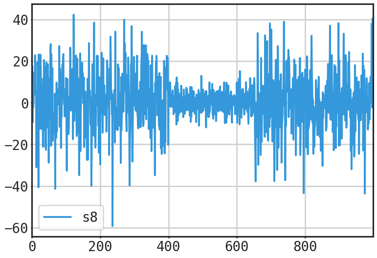

```python
Image(visual_dir / "s8.png")
```

```python
display(kpss_test(s8))
display(adf_test(s8))
```

```
 KPSS Result: The series is stationary
```

|  | test_stat | pval | 1% | 5% | 10% |
| --- | --- | --- | --- | --- | --- |
| s8 | 0.0971 | 0.1000 | 0.7390 | 0.4630 | 0.3470 |

```
 ADF Result: The series is stationary
```

|  | test_stat | pval | 1% | 5% | 10% |
| --- | --- | --- | --- | --- | --- |
| s8 | -29.8810 | 0.0000 | -3.9679 | -3.4149 | -3.1296 |

## How Asset Returns Violate Rules of Stationarity

Now that you are familiarized with the concept of stationary time series, the remainder of this notebook will demonstrate/discuss some of the nuances and challenges one runs into in when trying to predict time series.

Before we start just know that the behavior of securities' returns challenges these requirements of stationarity and our attempts to predict them in ways that are sometimes unknowable. This is a very humbling realization but is a necessary fact that requires a strategic response in the practice of return prediction.

### Do The Means and Standard Deviations vary with Time?

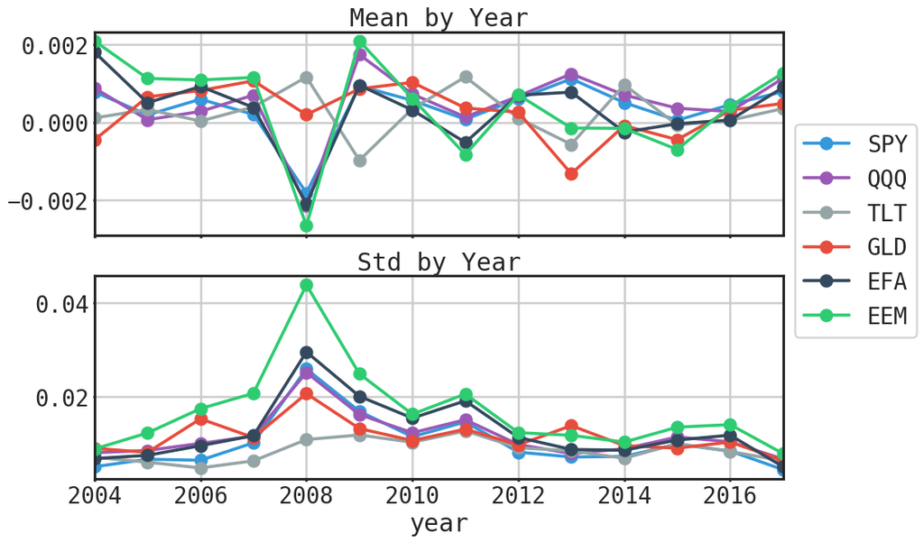

```python
Image(visual_dir / "mean_std_devs_by_year.png")
```

### The annual means and standard deviations vary signficantly across years.

One way we can examine whether the returns are stationary is looking at the mean and standard deviation of returns by year. If those two quantities are not supposed to be a function of time then they should be pretty similar across years, right?

### Examining Autocorrelation

Finally we can look for evidence of correlated data points by plotting the return series and its autocorrelation and partial autocorrelation function. We'll briefly look at plots by symbol and see if there are any correlated lags.

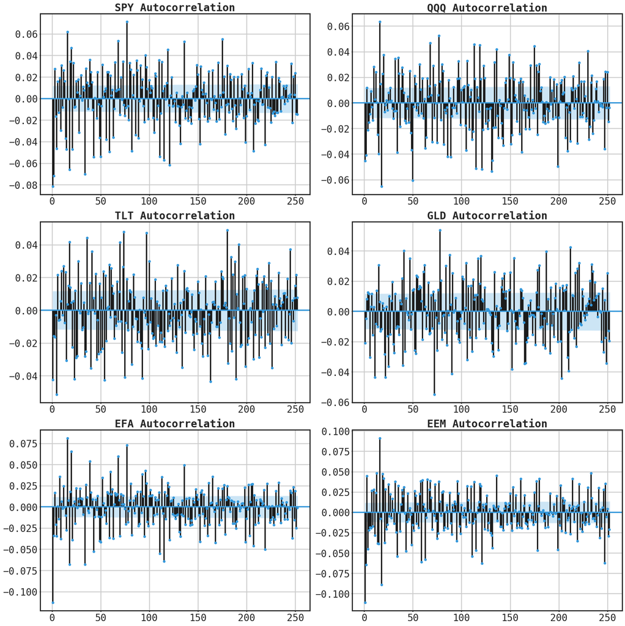

```python
Image(visual_dir / "acf_by_symbol.png", height=600, width=600)
```

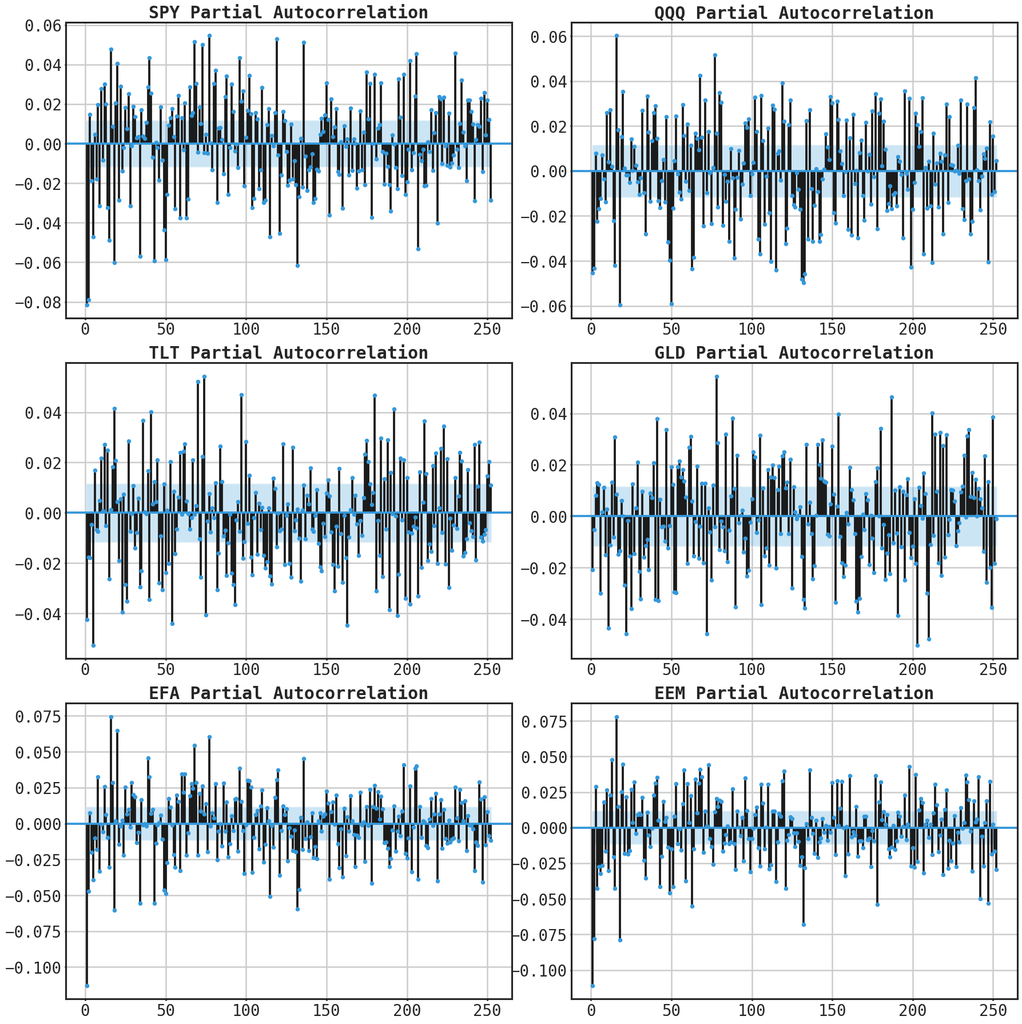

```python
Image(visual_dir / "pacf_by_symbol.png", height=600, width=600)
```

### What does this mean?

Imagine we have a basic mean reversion strategy and we use the previous year's mean and std deviation to set the parameters for our present strategy.

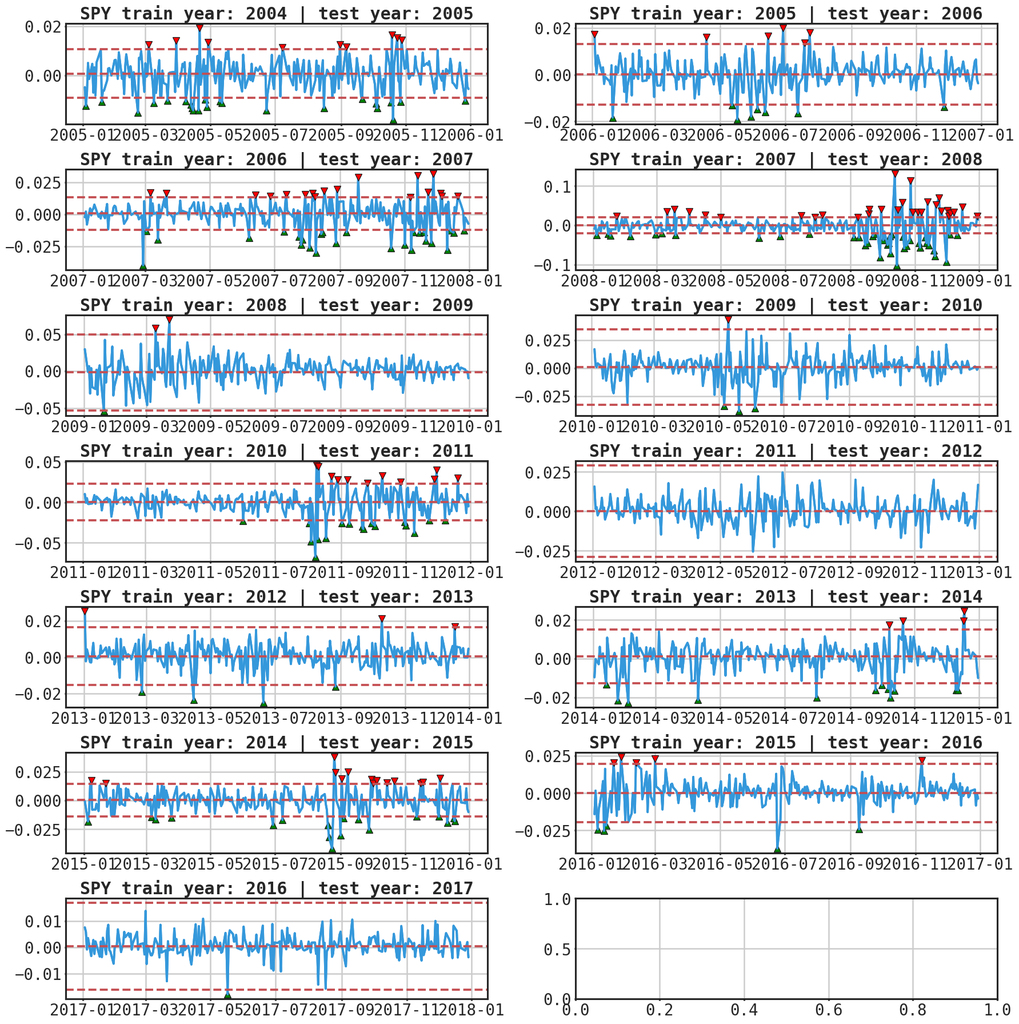

```python
Image(visual_dir / "SPY_mr_entry_example.png", height=800, width=800)
```

In the previous image we can see examples where there are lots of trades for some years and very few trades other years due to the previous years low or high volatility.

To get a better idea of some of the potential risks involved we can calculate an estimate of the maximum adverse selection for each entry point. This assumes you were able to enter at the moment price crossed the outer bands and calculates the maximum distance between price and the band over that period.

In the following plot we will see how some years and symbols the per trade drawdown is very high.

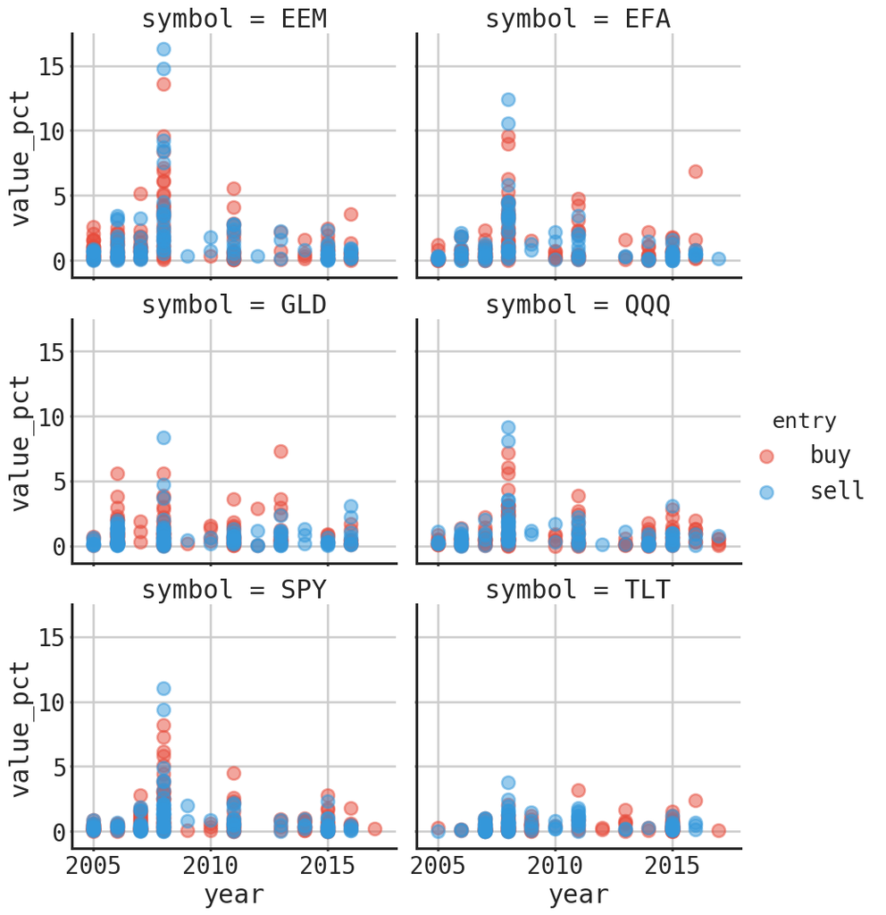

```python
Image(visual_dir / "mae.png", height=600, width=600)
```

Below highlights the variation in trade counts per year by symbol.

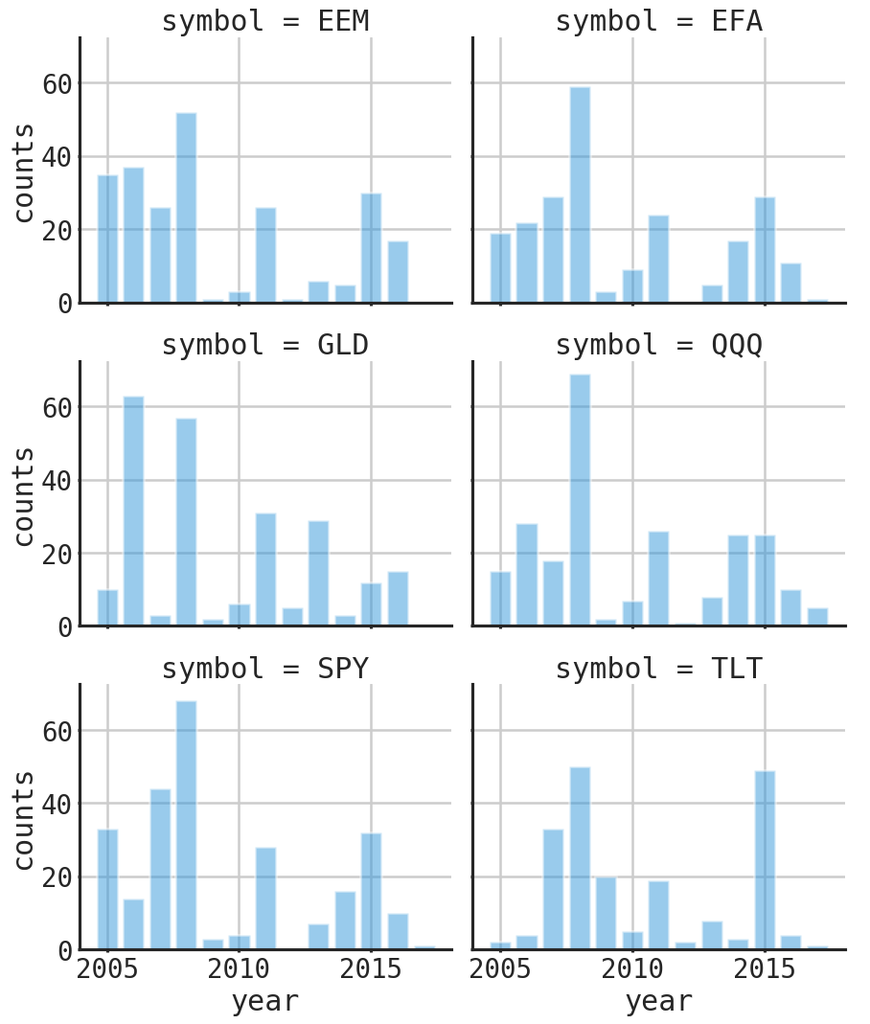

```python
Image(visual_dir / "trade_counts_facet_grid.png", height=500, width=500)
```

## Conclusions

Regarding asset returns we've seen that the means and variances are not stationary, and that there is autocorrelation between returns at differing lags, and multiple time scales. We've also seen how there is potential for large errors/losses if we assume that the return distribution from the previous period(s) to the next are the same because in most cases they are not.

Hopefully this notebook shows that there is a need for a modeling framework that can assist in overcoming these challenges in a robust manner. In the next chapter I hope to demonstrate how mixture models approach these issues and the potential benefits they bring to this task.

## Resources and Citations

1. https://www.seanabu.com/2016/03/22/time-series-seasonal-ARIMA-model-in-python/
2. https://pydata.github.io/pandas-datareader/stable/remote_data.html#tiingo
3. http://www.blackarbs.com/blog/time-series-analysis-in-python-linear-models-to-garch/11/1/2016